# Week 4 Submission

January 25, 2017

## Objective

The Objective of this application is to diagramatically display the growth of phone usage in the different geographic regions between 1951 and 1961.

For this purpose we use the WorldPhones dataset.

```
##      N.Amer Europe Asia S.Amer Oceania Africa Mid.Amer
## 1951  45939  21574 2876   1815    1646     89      555
## 1956  60423  29990 4708   2568    2366   1411      733
## 1957  64721  32510 5230   2695    2526   1546      773
## 1958  68484  35218 6662   2845    2691   1663      836
## 1959  71799  37598 6856   3000    2868   1769      911
## 1960  76036  40341 8220   3145    3054   1905     1008
## 1961  79831  43173 9053   3338    3224   2005     1076
```

WorldPhones provides information about the number of phones in the different regions and years in a matrix form.

## How to Use

The Shiny app can be accessed here - http://jayeshs81.shinyapps.io/Week4Submission

Our Shiny app, allows you to plot the # of phone depending on which years and regions you are interested in.

To use the Shiny app:  
- Select the Region(s) which you want to display in the plot  
- Select the Year(s) which you want to display in the plot

On changing the selection of the region or the year check boxes a new plot is created in the main panel.

## Displayed Plot

The plot displat a dodged bar plot of the number of phones for each of the selected years and region. A plot for all regions and years selected is shown below.

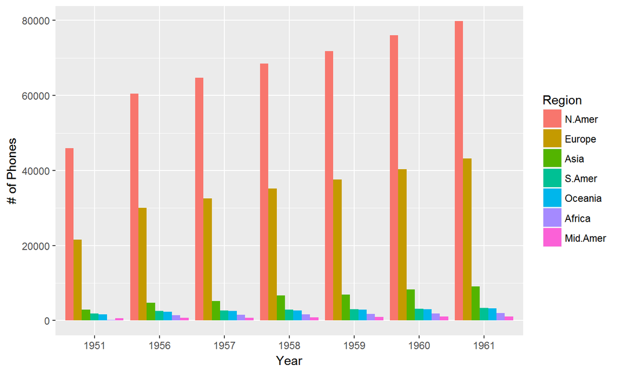